# Лабораторная работа №8

Текстовой редактор vi

Салькова К. М.

Российский университет дружбы народов, Москва, Россия

# Информация

## Докладчик

- Салькова Кристина Михайловна
- студентка НБИбд-04-22
- Российский университет дружбы народов

# Вводная часть

## Объект и предмет исследования

- Редактор vi

# Цель работы

## Цель работы

Познакомиться с операционной системой Linux. Получить практические навыки рабо- ты с редактором vi, установленным по умолчанию практически во всех дистрибутивах.

# Выполнение лабораторной работы

# Задание 1

## 1

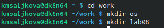

создание каталога

## 2

Перейдите во вновь созданный каталог.

cd

## 3

Вызовите vi и создайте файл hello.sh

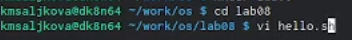

vi

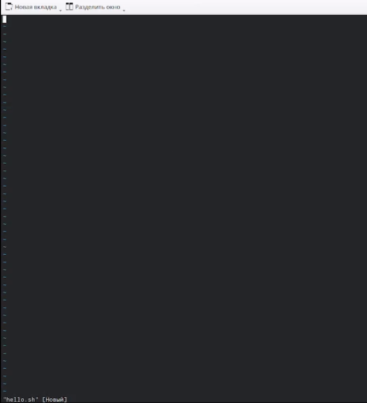

hello.sh

## 4

Нажмите клавишу i и вводите следующий текст.

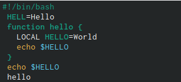

ввод текста

## 5

Нажмите клавишу Esc для перехода в командный режим после завершения ввода текста.

## 6

Нажмите : для перехода в режим последней строки и внизу вашего экрана появится приглашение в виде двоеточия

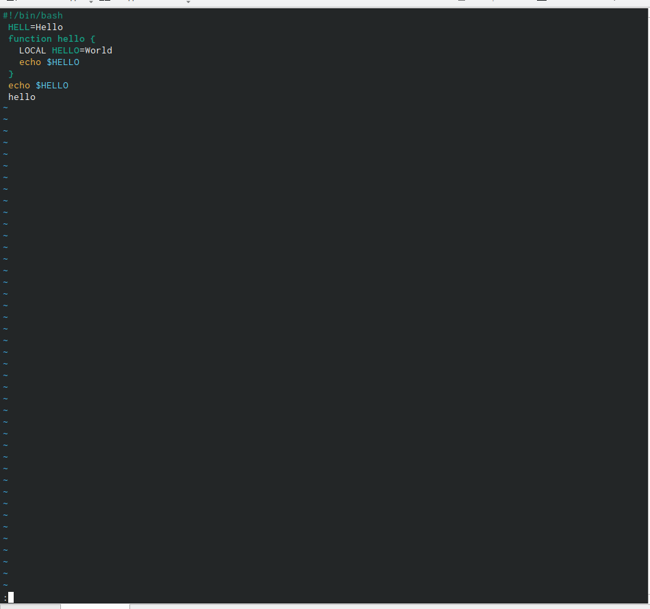

режим последней строки

## 7

Нажмите w (записать) и q (выйти), а затем нажмите клавишу Enter для сохранения вашего текста и завершения работы.

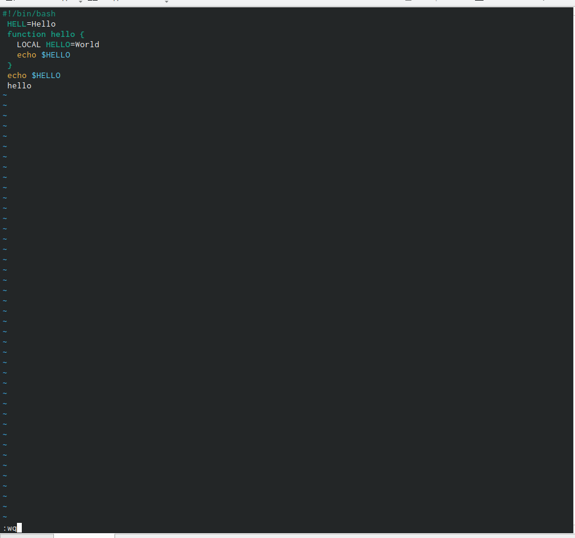

wq

## 8

Сделайте файл исполняемым

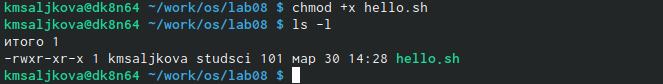

chmod

# Задание 2. Редактирование существующего файла

## 1

Вызовите vi на редактирование файла

## 2

Установите курсор в конец слова HELL второй строки.

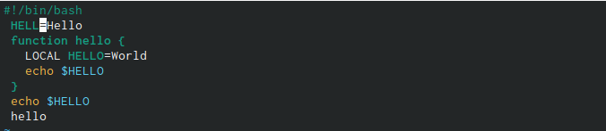

курсор в конце HELL

## 3

Перейдите в режим вставки и замените на HELLO. Нажмите Esc для возврата в команд- ный режим.

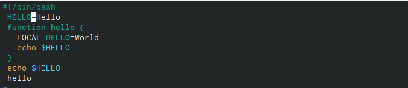

заменим на HELLO

## 4

Установите курсор на четвертую строку и сотрите слово LOCAL.

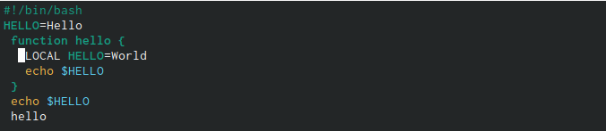

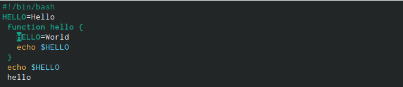

## 5

Перейдите в режим вставки и наберите следующий текст: local, нажмите Esc для возврата в командный режим.

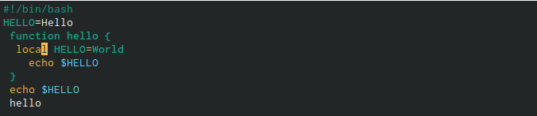

local

## 6

Установите курсор на последней строке файла. Вставьте после неё строку, содержащую следующий текст: echo $HELLO.

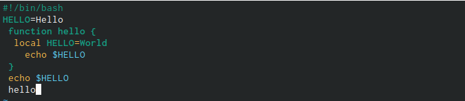

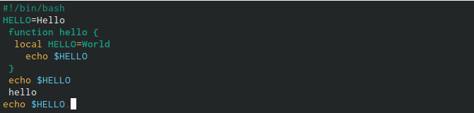

## 7

Нажмите Esc для перехода в командный режим.

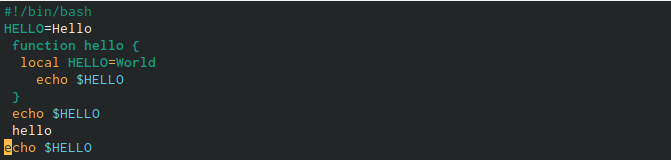

переход в командный режим

## 8

Удалите последнюю строку.

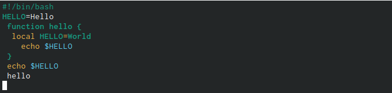

удвление строки

## 9

Введите команду отмены изменений u для отмены последней команды.

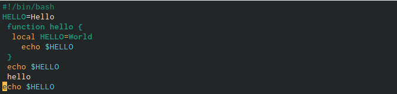

отмена команды

## 10

Введите символ : для перехода в режим последней строки. Запишите произведённые изменения и выйдите из vi.

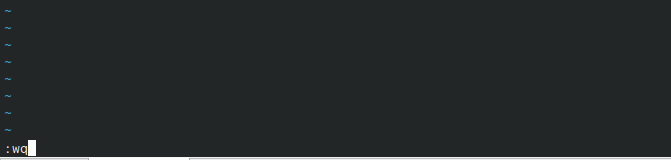

выход из vi

# Вывод

## Выводы

Мы познакомились с операционной системой Linux. Получили практические навыки работы с редактором vi, установленным по умолчанию практически во всех дистрибутивах.